# PK Analysis Sample for Single Ascending Dose Data

```r
## Load needed libraries
libraries <- c("tidyverse","ggplot2","shiny","shinydashboard","xgxr","dplyr","DBI","tidyr","stringr","ggpubr","gridExtra","xgxr")
for (l in libraries) {
  suppressPackageStartupMessages(library(l, character.only = TRUE))
}
```

## Introduction

Analysis of biometric data from pharmacokinetics experiment of the anti-asthmatic drug theophylline.

```r
data(Theoph)
```

Additional datasets:

- demog.csv: demographics dataset characterizing the subjects
- il5.csv: This dataset contains % inhibition of stimulated IL-5 release by PBMC at hour 0 and hour 24.

**Data join on theophylline data.**

- a_Theoph includes all subjects’ data in Theoph joined with demographic data (using the correct dplyr join function) from dm.csv and il5 inhibition data from il5.csv.
- Included only the subjects from Theoph in the resulting joined dataset. Subjects in Theoph will be included in the analysis population.
- Created data frame a_Theoph with the following columns:
  - Subject: Subject ID from Theoph
  - SEX: Sex from dm.csv
  - Age: Age from dm.csv
  - Dose: Dose from Theoph
  - Time: Time from Theoph
  - Conc: conc from Theop
  - il5PCTI: % IL-5 inhibition from il5.csv

Generating a_Theoph:

```r
##input analysis data creation code here
#clean up and harmonize dataframes for join
dm <- read.csv("dm.csv")
#harmonize columns to join
colnames(dm)[1]<-colnames(Theoph)[1]
#removed repeating values for subjects and values are acceptable
unique(dm$Subject)
```

```
##  [1]  1  2  3  4  5  6  7  8  9 10 11 12 14 18
```

```r
dm%>%filter(Age>100)
```

```
##   Subject SEX      Age AgeUnits
## 1       6   F 153.0842    YEARS
## 2      10   M 148.3626    YEARS
```

```r
dm %>% filter(Subject == 10)
```

```
##   Subject SEX       Age AgeUnits
## 1      10   M  48.36263    YEARS
## 2      10   M 148.36263    YEARS
```

```r
#subject 10 had repeating value with 1 placed before age, subject 6 presumably had the same error. Both subjects demog data require the same correction of 1 removed from the Age value
dm[!(dm$Subject == 10 & dm$Age>100),]->dm
dm[dm$Subject == 6,'Age']
```

```
## [1] 153.0842
```

```r
dm[dm$Subject == 6,'Age']<-53.0842
il5 <- read.csv("il5.csv")
#fix header columns

il5 %>%mutate_all(as.numeric)->il5
```

```r
#join data
#Missingness in cross comparison across demog and il5 dataframes
setdiff(dm$Subject,il5$Subject)
```

```
## [1] 11 12 14 18
```

```r
#11 12 14 18 only in dm
left_join(dm,il5)->dm_comb
colnames(dm_comb)<-c('Subject','SEX','Age','AgeUnits','Hour 0','Hour 24')
#Converted time for IL-5 inibition to same units as Theoph df and clean up gender column
dm_comb->bkup
dm_comb %>% group_by(Subject)%>%gather(key="Time_cat",value="IL5_inhb_prct",-c(Subject:AgeUnits))->dm_comb

gsub("MALE","M",dm_comb$SEX)->dm_comb$SEX
#Assess missingness in dm and Theoph dataframes
setdiff(dm_comb$Subject,Theoph$Subject)
```

```
## [1] 14 18
```

```r
setdiff(Theoph$Subject, dm_comb$Subject)
```

```
## character(0)
```

```r
#14, 18 only in dm_comb and do not have any conc values for Theoph or IL-5 and subsects 11 and 12 have no IL-5 concentration values
#drop subject 14 and 18 from all subsequent joined datasets
dm_comb[!dm_comb$Subject %in% c(14,18),]->dm_comb
#convert Theoph
as.data.frame(Theoph)->a_Theoph
colnames(a_Theoph)[5]<-"Theop_conc"
str(a_Theoph)
```

```
## 'data.frame':    132 obs. of  5 variables:
##  $ Subject   : Ord.factor w/ 12 levels "6"<"7"<"8"<"11"<..: 11 11 11 11 11 11 11 11 11 11 ...
##  $ Wt        : num  79.6 79.6 79.6 79.6 79.6 79.6 79.6 79.6 79.6 79.6 ...
##  $ Dose      : num  4.02 4.02 4.02 4.02 4.02 4.02 4.02 4.02 4.02 4.02 ...
##  $ Time      : num  0 0.25 0.57 1.12 2.02 ...
##  $ Theop_conc: num  0.74 2.84 6.57 10.5 9.66 8.58 8.36 7.47 6.89 5.94 ...
##  - attr(*, "formula")=Class 'formula'  language conc ~ Time | Subject
##   .. ..- attr(*, ".Environment")=<environment: R_EmptyEnv>
##  - attr(*, "labels")=List of 2
##   ..$ x: chr "Time since drug administration"
##   ..$ y: chr "Theophylline concentration in serum"
##  - attr(*, "units")=List of 2
##   ..$ x: chr "(hr)"
##   ..$ y: chr "(mg/l)"
```

```r
as.numeric(paste(a_Theoph$Subject))->a_Theoph$Subject
#convert time to categorical to join the dm_comb df
#max value to convert for earliest time point equivalent to hour 0
a_Theoph %>% group_by(Subject)%>%arrange(Time)%>%slice(1)%>%select(Time)%>%drop_na()%>%ungroup%>%pull(Time)%>%max()
```

```
## [1] 0
```

```r
#value =0
#min value to convert for latest time point equivalent to hour 24
a_Theoph %>% group_by(Subject)%>%arrange(desc(Time))%>%slice(1)%>%select(Time)%>%drop_na()%>%ungroup%>%pull(Time)%>%min()
```

```
## [1] 23.7
```

```r
#value=23.7

a_Theoph%>%filter(Time >=23.7)%>%nrow()
```

```
## [1] 12
```

```r
a_Theoph$Time_cat<-""
a_Theoph[a_Theoph$Time == 0,'Time_cat']<-"Hour 0"
a_Theoph[a_Theoph$Time >=23.7,'Time_cat']<-"Hour 24"
###

#saved

# View(a_Theoph)
# View(Theoph)
# View(dm_comb)
a_Theoph->a_Theoph_bkup1
```

```r
as.data.frame(dm_comb)->dm_comb
unique(dm_comb[,c("Subject","Age","SEX")])->tmp_df
left_join(a_Theoph,tmp_df)->a_Theoph
left_join(a_Theoph,dm_comb)->a_Theoph
a_Theoph->a_Theoph_bkup
#clean up a_Theoph and rename cols
a_Theoph%>%select(-c(AgeUnits,Wt,Time_cat))%>%select(c(1,6,5,2:3,4,7))->a_Theoph
colnames(a_Theoph)[6:7]<-c("Conc","il5PCTI")
a_Theoph->a_Theoph_bkup2
```

Data overview

Print the structural summary of the data frame a_Theoph.

```r
cat("\n\n Summary of a_Theoph")
```

```
##
##
##  Summary of a_Theoph
```

```r
#str(a_Theoph)
summary(a_Theoph)
```

```
##     Subject          SEX                 Age             Dose
##  Min.   : 1.00   Length:132         Min.   :32.83   Min.   :3.100
##  1st Qu.: 3.75   Class :character   1st Qu.:42.42   1st Qu.:4.305
##  Median : 6.50   Mode  :character   Median :47.32   Median :4.530
##  Mean   : 6.50                      Mean   :47.67   Mean   :4.626
##  3rd Qu.: 9.25                      3rd Qu.:53.82   3rd Qu.:5.037
##  Max.   :12.00                      Max.   :66.52   Max.   :5.860
##
##       Time             Conc           il5PCTI
##  Min.   : 0.000   Min.   : 0.000   Min.   :2.000
##  1st Qu.: 0.595   1st Qu.: 2.877   1st Qu.:4.000
##  Median : 3.530   Median : 5.275   Median :5.000
##  Mean   : 5.895   Mean   : 4.960   Mean   :4.925
##  3rd Qu.: 9.000   3rd Qu.: 7.140   3rd Qu.:6.000
##  Max.   :24.650   Max.   :11.400   Max.   :7.000
##                                    NA's   :112
```

## Data Overview

```r
##input summary data code and brief written summary here.
gg1<-ggplot(a_Theoph,aes(Time,Conc,color=SEX,group=Subject))+geom_point()+geom_line()+theme_bw()+ylab("Theophylline (mg/ml)")+ggtitle("Theophylline concentrations stratified by gender")
a_Theoph %>%group_by(SEX)%>%summarise(n=n_distinct(Subject),min_conc=min(Conc),max_conc=max(Conc),mean_conc=mean(Conc),median_conc=median(Conc),sd=sd(Conc))->By_gen_theophconc_sum
row
```

[output not shown]

```r
#print(gg1)
#By_gen_theophconc_sum
rownames(By_gen_theophconc_sum)<-c(""," ")
```

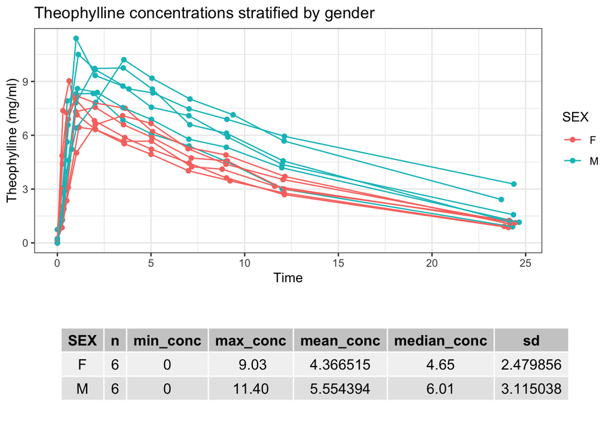

```r
grid.arrange(gg1,tableGrob(By_gen_theophconc_sum),nrow=2,heights=c(1.5,.75))
```

```r
#outputplot1<-grid.arrange(gg1,tableGrob(By_gen_theophconc_sum),nrow=2,heights=c(1.5,.75))
```

## Calculate AUC

AUC (based on the linear trapezoidal rule) applied to a_Theoph.

```r
trapezoid <- function(indf) {

  outdf <- indf %>%
    group_by(Subject) %>%
    mutate(conc2 = ifelse(Time>0,lag(Conc),0),time2=ifelse(Time>0,lag(Time),0))%>%mutate(Trap=((Time-time2)*(Conc+conc2))/2)%>%mutate(AUC=cumsum(Trap))
##

  return(outdf %>% as.data.frame())
}

trapezoid(a_Theoph)->AUC_calc_ref
trapezoid(a_Theoph)->a_Theoph
```

The structural summary of the revised data frame a_Theoph and the single AUC per subject.

```r
a_Theoph%>%select(-c(conc2:Trap))->a_Theoph
cat("\n\n Summary of a_Theoph with new column AUC")
```

```
##
##
##  Summary of a_Theoph with new column AUC
```

```r
str(a_Theoph)
```

```
## 'data.frame':    132 obs. of  8 variables:
##  $ Subject: num  1 1 1 1 1 1 1 1 1 1 ...
##  $ SEX    : chr  "M" "M" "M" "M" ...
##  $ Age    : num  32.8 32.8 32.8 32.8 32.8 ...
##  $ Dose   : num  4.02 4.02 4.02 4.02 4.02 4.02 4.02 4.02 4.02 4.02 ...
##  $ Time   : num  0 0.25 0.57 1.12 2.02 ...
##  $ Conc   : num  0.74 2.84 6.57 10.5 9.66 8.58 8.36 7.47 6.89 5.94 ...
##  $ il5PCTI: num  2 NA NA NA NA NA NA NA NA NA ...
##  $ AUC    : num  0 0.448 1.953 6.647 15.719 ...
```

```r
summary(a_Theoph)
```

```
##     Subject          SEX                 Age             Dose
##  Min.   : 1.00   Length:132         Min.   :32.83   Min.   :3.100
##  1st Qu.: 3.75   Class :character   1st Qu.:42.42   1st Qu.:4.305
##  Median : 6.50   Mode  :character   Median :47.32   Median :4.530
##  Mean   : 6.50                      Mean   :47.67   Mean   :4.626
##  3rd Qu.: 9.25                      3rd Qu.:53.82   3rd Qu.:5.037
##  Max.   :12.00                      Max.   :66.52   Max.   :5.860
##
##       Time             Conc           il5PCTI           AUC
##  Min.   : 0.000   Min.   : 0.000   Min.   :2.000   Min.   :  0.000
##  1st Qu.: 0.595   1st Qu.: 2.877   1st Qu.:4.000   1st Qu.:  2.181
##  Median : 3.530   Median : 5.275   Median :5.000   Median : 24.334
##  Mean   : 5.895   Mean   : 4.960   Mean   :4.925   Mean   : 32.732
##  3rd Qu.: 9.000   3rd Qu.: 7.140   3rd Qu.:6.000   3rd Qu.: 56.159
##  Max.   :24.650   Max.   :11.400   Max.   :7.000   Max.   :148.923
##                                    NA's   :112
```

```r
cat("\n\n Print AUC per subject")
```

```
##
##
##  Print AUC per subject
```

```r
a_Theoph %>%group_by(Subject)%>%arrange(desc(Time))%>%slice(1)%>%select(Subject,AUC)%>%as.data.frame()
```

```
##    Subject       AUC
## 1        1 148.92305
## 2        2  91.52680
## 3        3  99.28650
## 4        4 106.79630
## 5        5 121.29440
## 6        6  73.77555
## 7        7  90.75340
## 8        8  88.55995
## 9        9  86.32615
## 10      10 138.36810
## 11      11  80.09360
## 12      12 119.97750
```

## Visualization: AUC

Visualizations showing concentration change over time as this is a PK experiment.

```r
#estimate AUC, normalized dose, Cmax, convert dose and time to categorical values
ntile(a_Theoph$Dose,3)%>% { gsub("1","low dose", .) } %>%{ gsub("2","middle dose", .) }%>%{ gsub("3","high dose", .) }->a_Theoph$Dose_cat
a_Theoph %>%mutate(Dose_cat2 = factor(Dose_cat, levels = unique(Dose_cat)))->a_Theoph
a_Theoph %>%group_by(Subject)%>%arrange(desc(Time))%>%slice(1)%>%select(Subject,SEX,AUC,Dose,Dose_cat2)%>%as.data.frame()->AUClast_df
a_Theoph %>%group_by(Subject)%>%arrange(desc(Conc))%>%slice(1)%>%as.data.frame()->Cmax_df
colnames(Cmax_df)[6]<-"Cmax"

#a_Theoph %>%mutate(Dose_cat2 = factor(Dose_cat, levels = unique(Dose_cat)))->a_Theoph
a_Theoph %>%mutate(Norm_conc=Conc/Dose)->a_Theoph
#convert time to categorical
unique(a_Theoph[,c("Subject","Time")])->rb
rb%>%group_by(Subject)%>%mutate(row_num=row_number())%>%as.data.frame()->rb
rb%>%group_by(row_num)%>%summarise(min=min(Time),max=max(Time),mean=mean(Time))%>%mutate(Time_val=ifelse(mean>1,round(mean),mean))->Timevalsum
a_Theoph%>%group_by(Subject)%>%mutate(row_num=row_number())%>%as.data.frame()->a_Theoph
left_join(a_Theoph,Timevalsum[,c('row_num','Time_val')])->a_Theoph
```

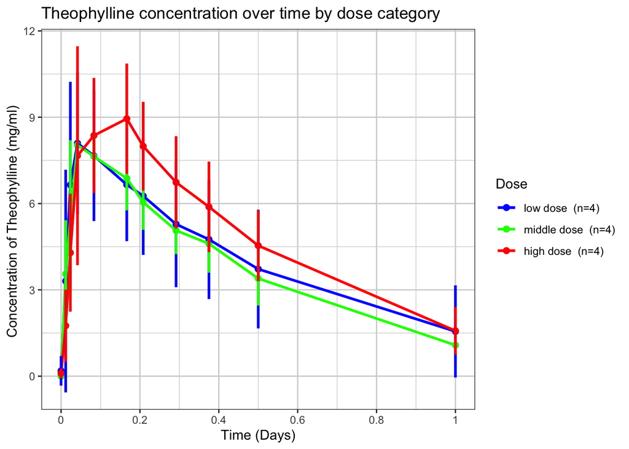

```r
##input code here
#reg plots, plot break up conc by bin
xgx_theme_set()
"hours"->time_units_dataset
"days"->time_units_plot
gg2<-ggplot(a_Theoph,aes(Time_val,Conc,color=Dose_cat2,group=Dose_cat2))+ xgx_stat_ci(conf_level = .95)+ xgx_scale_x_time_units(units_dataset = time_units_dataset, units_plot = time_units_plot)+scale_color_manual(name="Dose",values=c("blue","green", "red"),labels=paste(unique(a_Theoph$Dose_cat2)," (n=4)"))+ylab("Concentration of Theophylline (mg/ml) ")+ggtitle("Theophylline concentration over time by dose category")

gg3<-ggplot(a_Theoph,aes(Time_val,Norm_conc,color=Dose_cat2,group=Dose_cat2))+ xgx_stat_ci(conf_level = .95)+ xgx_scale_x_time_units(units_dataset = time_units_dataset, units_plot = time_units_plot)+scale_color_manual(name="Dose",values=c("blue","green", "red"),labels=paste(unique(a_Theoph$Dose_cat2)," (n=4)"))+ylab("Normalized concentration of Theophylline ")+ggtitle("Normalized concentration of Theophylline over time by dose category")

gg4<-ggplot(AUClast_df,aes(SEX,AUC,group=SEX,fill=SEX))+geom_boxplot()+scale_fill_manual(name="Gender",values=c("salmon","gray"))+xlab("Gender")+ggtitle("")
gg5<-ggplot(Cmax_df,aes(SEX,Cmax,group=SEX,fill=SEX))+geom_boxplot()+scale_fill_manual(name="Gender",values=c("salmon","gray"))+xlab("Gender")+ggtitle("")

gg6<-ggscatter(Cmax_df,"Cmax","Dose",add="reg.line")+stat_cor(label.y = 7)+stat_regline_equation(label.y = 6.75)+ggtitle("Linear relationship between Cmax and Dose")+theme(plot.title = element_text(size =10))
gg7<-ggscatter(AUClast_df,"AUC","Dose",add="reg.line")+stat_cor(label.y = 7.4) +stat_regline_equation(label.y = 7)+ggtitle("Linear relationship between AUC and Dose")+theme(plot.title = element_text(size =10))
gg2
```

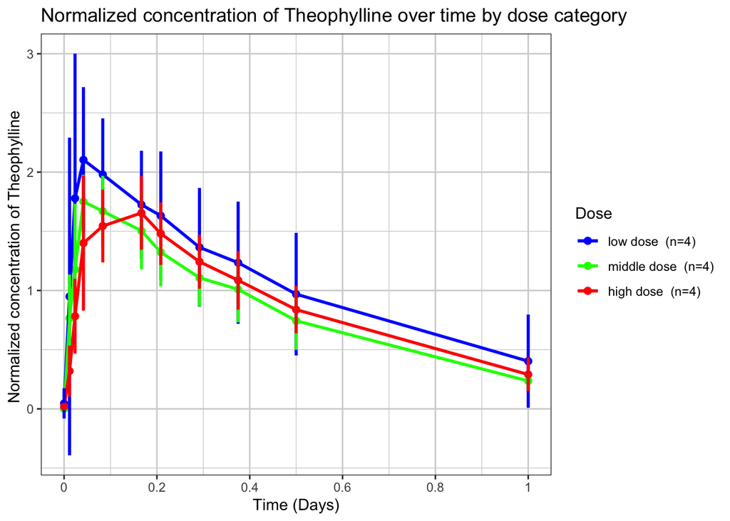

```r
gg3
```

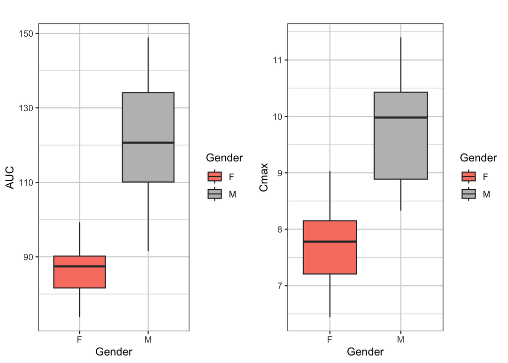

```r
grid.arrange(gg4,gg5,ncol=2)
```

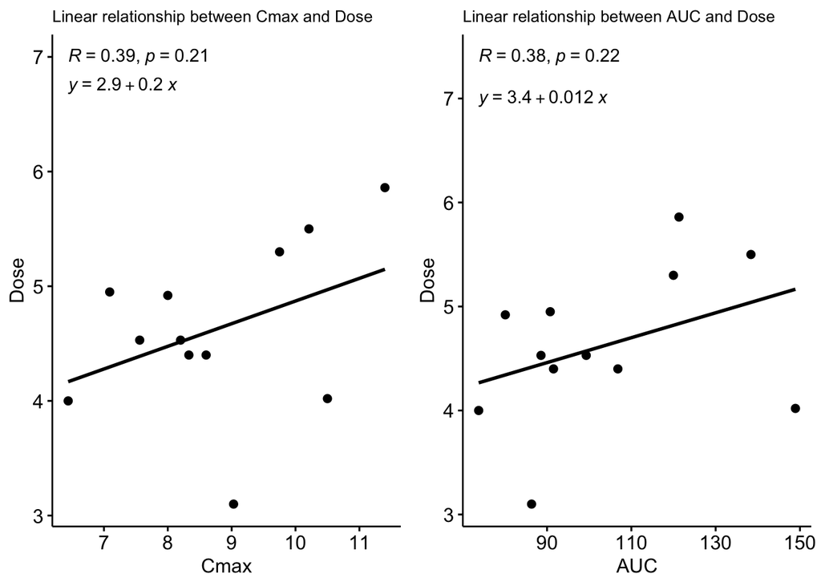

```r
grid.arrange(gg6,gg7,ncol=2)
```

## Analysis: AUC

Estimates of the pharmacokinetic (PK) property, area under the curve (AUC), for the drug Theophylline based on the available data.

## PK Analysis assumptions

1.) Trends examined from dose-dependent pharmacokinetic data assumes subjects respond similarly to drug irrespective of age, gender and other potentially confounding covariates. Also interpretation is limited by low N in each group. 2.) Numeric dose was broken into tertiles and tertiles were assumed to correspond to categorical designation of incremental dose increase of low, middle and high dose. 3.) Time values converted to categorical values (binned) with solution provided in above code.

```r
##input code for estimating AUC here.
#a_Theoph %>%group_by(Subject)%>%arrange(desc(Time))%>%slice(1)%>%select(Subject,AUC)%>%as.data.frame()->AUClast_df
summary(AUClast_df)
```

```
##     Subject          SEX                 AUC              Dose
##  Min.   : 1.00   Length:12          Min.   : 73.78   Min.   :3.100
##  1st Qu.: 3.75   Class :character   1st Qu.: 88.00   1st Qu.:4.305
##  Median : 6.50   Mode  :character   Median : 95.41   Median :4.530
##  Mean   : 6.50                      Mean   :103.81   Mean   :4.626
##  3rd Qu.: 9.25                      3rd Qu.:120.31   3rd Qu.:5.037
##  Max.   :12.00                      Max.   :148.92   Max.   :5.860
##        Dose_cat2
##  low dose   :4
##  middle dose:4
##  high dose  :4
##
##
##
```

```r
AUClast_df %>%group_by(SEX)%>%summarise(median(AUC),IQR(AUC))
```

```
## # A tibble: 2 × 3
##   SEX   `median(AUC)` `IQR(AUC)`
##   <chr>         <dbl>      <dbl>
## 1 F              87.4       8.55
## 2 M             121.       24.0
```

### **Interpretation of PK and AUC data**

Concentration of Theophylline by dose category shows those in the high dose group achieve higher concentrations over 24 hr than the other two lower dose groups, but this is slightly lagged in comparison to lower dose groups which suggests slower absorption. This is further reinforced by the normalized concentration of Theophylline by dose category plot,which shows better absorption of the low dose groups. Overall AUC also shows an gender effect with median (IQR) values lower for females than for males,87.4 (8.5) and 121 (24), respectively.The same was trend was observed for Cmax. Due to low N and lack of robust trend, a weak non-significant linear relationship with both AUC and Cmax were observed with numeric dose values.

## Visualization: Theophylline Concentration and Inhibitory Effect on IL-5 Production

```r
##input code here
#Calculate change in % inhibition of IL-5 from baseline
a_Theoph %>% group_by(Subject,SEX,Dose,Dose_cat2)%>%summarise(Change_in_il5inb=il5PCTI[row_num == 11]-il5PCTI[row_num == 1])%>%arrange(Change_in_il5inb)%>%drop_na(Change_in_il5inb)%>%as.data.frame()->il5summary
left_join(il5summary,Cmax_df[,c("Subject","Cmax")])%>%left_join(.,AUClast_df[,c("Subject","AUC")])->il5summary
```

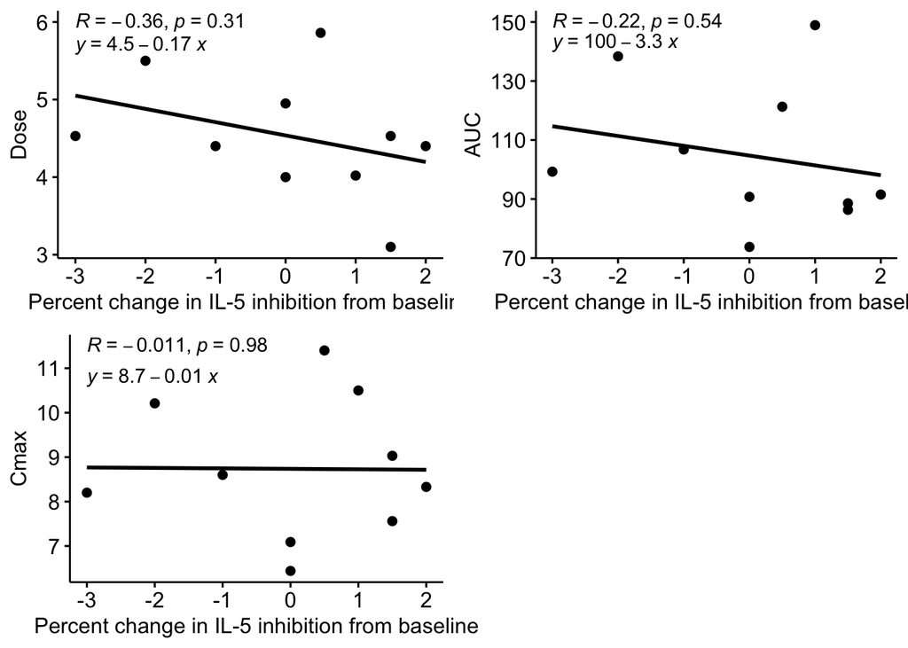

```r
#relationship between change il5 inhibition and Dose
gg8<-ggscatter(il5summary,"Change_in_il5inb","Dose",add="reg.line")+stat_cor(label.y = 6) +stat_regline_equation(label.y = 5.7)+xlab("Percent change in IL-5 inhibition from baseline")
#relationship between change il5 inhibition and AUC
gg9<-ggscatter(il5summary,"Change_in_il5inb","AUC",add="reg.line")+stat_cor(label.y = 150) +stat_regline_equation(label.y = 143)+xlab("Percent change in IL-5 inhibition from baseline")
#relationship between change il5 inhibition and Cmax
gg10<-ggscatter(il5summary,"Change_in_il5inb","Cmax",add="reg.line")+stat_cor(label.y = 11.5) +stat_regline_equation(label.y =10.8)+xlab("Percent change in IL-5 inhibition from baseline")

grid.arrange(gg8,gg9, gg10,ncol=2)
```

### **Interpretation of IL-5 inhibition and correlations**

Overall no significant relationships were observed between percent change of IL-5 inhibition from baseline with numeric dose, AUC, and Cmax. With dose and AUC, an inverse non-significant linear relationship was observed between percent change of IL-5 inhibition from baseline.

```r
save.image("PKIL5.RData")
```